# Differential Expression Analysis (Tabbed Report)

**Abundance Distributions**

[interactive chart not shown]

Figure 5: Raw and transformed abundance distributions. Each curve represents one sample; the x-axes show raw abundance and transformed intensity, and the y-axes show kernel density.

**Variance**

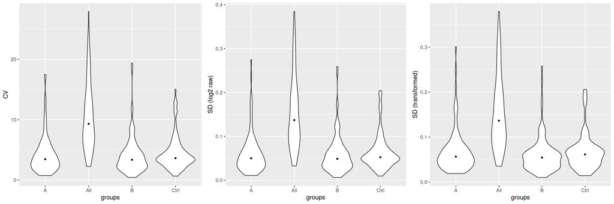

Figure 6: Raw feature abundance CV, log2 raw feature abundance SD, and transformed feature abundance SD distributions.

Table 5

| source | probs | A | B | Ctrl | All |
| --- | --- | --- | --- | --- | --- |
| raw_cv | 0.1 | 1.498 | 1.532 | 1.848 | 4.05 |
| raw_cv | 0.25 | 2.215 | 2.133 | 2.946 | 6.501 |
| raw_cv | 0.5 | 3.471 | 3.371 | 3.64 | 9.324 |
| raw_cv | 0.75 | 5.13 | 4.767 | 5.115 | 13.429 |
| raw_cv | 0.9 | 7.782 | 7.99 | 7.559 | 18.892 |
| log2_sd | 0.1 | 0.022 | 0.022 | 0.027 | 0.059 |
| log2_sd | 0.25 | 0.032 | 0.031 | 0.043 | 0.094 |
| log2_sd | 0.5 | 0.05 | 0.049 | 0.052 | 0.137 |
| log2_sd | 0.75 | 0.074 | 0.068 | 0.074 | 0.194 |
| log2_sd | 0.9 | 0.112 | 0.118 | 0.113 | 0.285 |

[output cut: 5 more lines]

**Sample Structure**

**PCA**

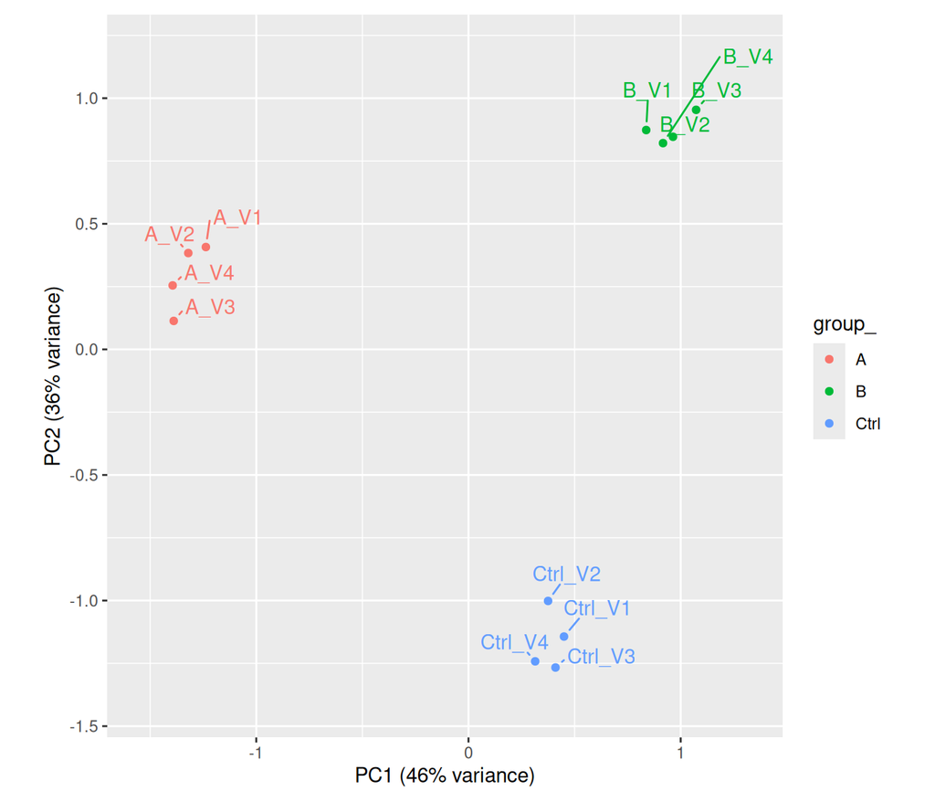

Figure 7: PCA of transformed feature abundances; each point is a sample plotted on PC1 versus PC2 (percent variance shown on the axes) and coloured by experimental group (features with missing values are removed).

**Correlation**

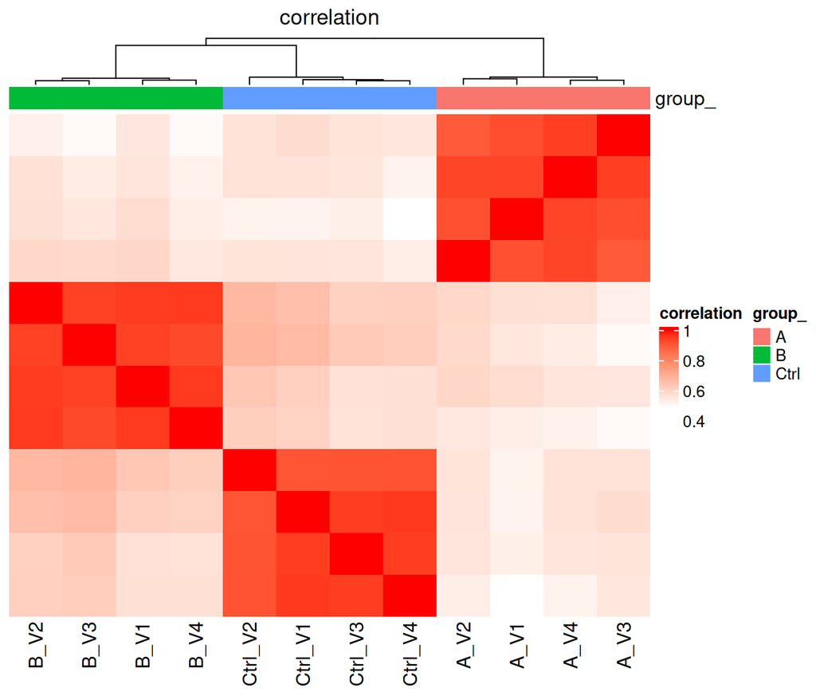

Figure 8: Sample correlation heatmap for transformed feature abundances.

**Abundance Heatmap**

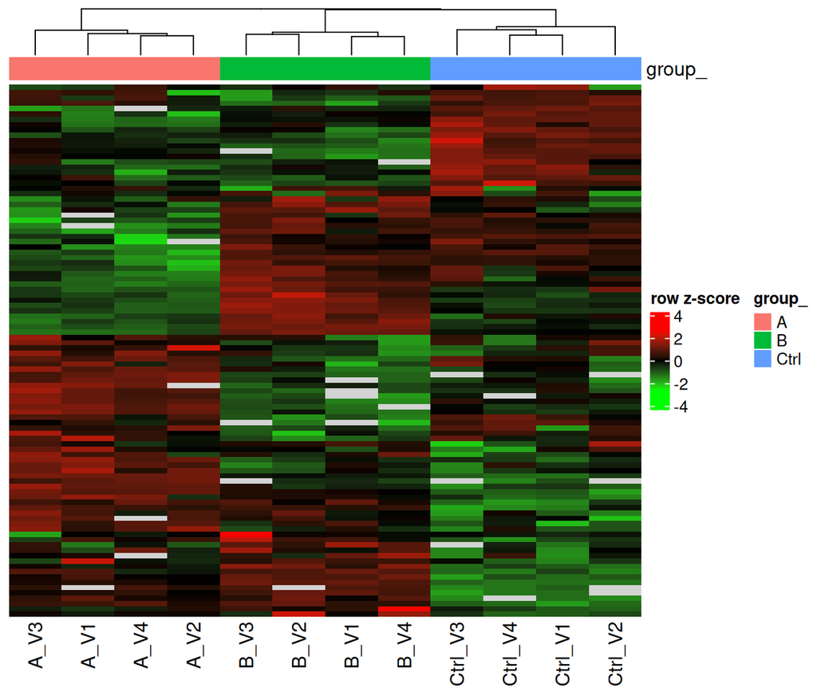

Figure 9: Heatmap of transformed feature abundances. Cell color encodes the row z-score on a green-black-red scale (green: low, black: average, red: high); missing values are shown in light gray.

**Differential Abundance**

**Summary**

Table 6

| contrast | direction | features |
| --- | --- | --- |
| AVsC | decreased | 5 |
| AVsC | increased | 10 |
| BVsC | decreased | 2 |
| BVsC | increased | 6 |

Table 7

| contrast | tested | significant | not_significant |
| --- | --- | --- | --- |
| AVsC | 100 | 15 | 85 |
| BVsC | 100 | 8 | 92 |

## Contrast Agreement

**All**

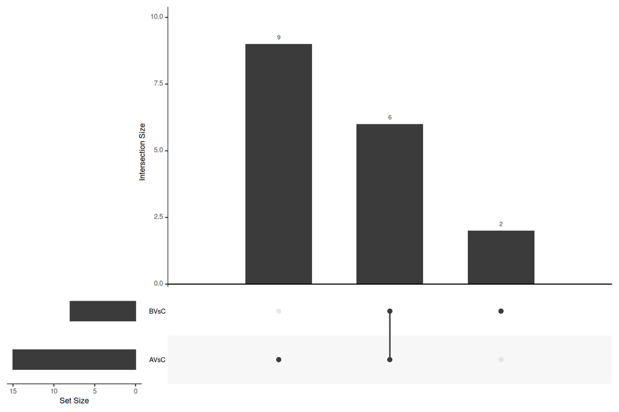

Figure 10: UpSet plot of significant features (both FDR and fold-change thresholds met, either direction) shared between contrasts: each vertical bar counts the features called significant in one specific combination of contrasts, shown by the filled dots below the bar, and the horizontal set-size bars on the left give each contrast’s total number of significant features.

### Increased

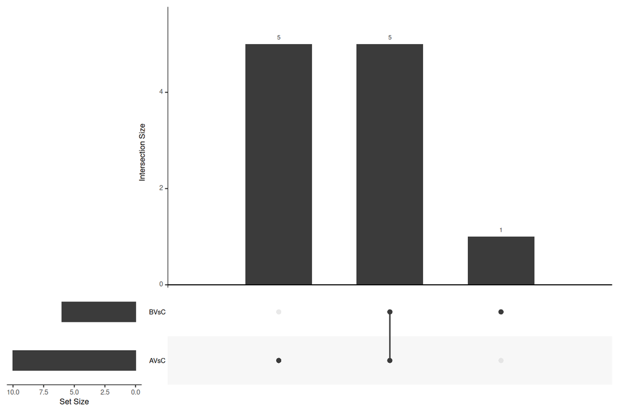

Figure 11: UpSet plot of significantly increased-abundance features (positive fold-change passing both thresholds) shared between contrasts: each vertical bar counts the up-regulated features in one specific combination of contrasts, shown by the filled dots below the bar, and the horizontal set-size bars on the left give each contrast’s total number of up-regulated features.